# Lezione DAG

##### Set-up

Codice per installare i pacchetti

```r
install.packages("dagitty")
install.packages("ggdag")
install.packages("tidyverse")
```

Codice per caricare i pacchetti:

```r
library(dagitty)
library(ggdag)
library(tidyverse)

# NB: il file tra virgolette deve essere nella stessa cartella di questo documento
load(file = "datilezione.Rdata")
```

# Elemental Confounders

## Relazioni base a due nodi

### 2 nodi indipendenti

Due nodi possono essere causalmente indipendenti o dipendenti.

Possiamo rappresentare due variabili indipendenti come due distribuzioni normali. Generiamo dati da queste:

```r
# consente la riproducibilità dei dati casuali
set.seed(1)

# numero di campioni
n <- 100

# genero due distribuzioni normali indipendenti
ind <- data.frame(x = rnorm(n),
                  y = rnorm(n))
# restituisce i primi elementi del data-frame
head(ind)
```

|  | x | y |
| --- | --- | --- |
| 1 | -0.6264538 | -0.62036668 |
| 2 | 0.1836433 | 0.04211587 |
| 3 | -0.8356286 | -0.91092165 |
| 4 | 1.5952808 | 0.15802877 |
| 5 | 0.3295078 | -0.65458464 |
| 6 | -0.8204684 | 1.76728727 |

Plottiamo i dati giusto per vedere che faccia hanno:

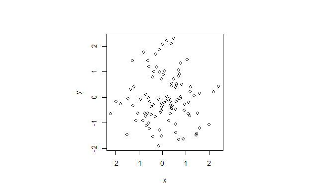

```r
par(pty = "s")
plot(y~x, data = ind)
```

non si vede nessun trend come previsto.

Data l’indipendenza delle variabili, queste possono essere rappresentate attraverso un DAG come due nodi disuniti. Il codice per generare questo DAG con R è il seguente:

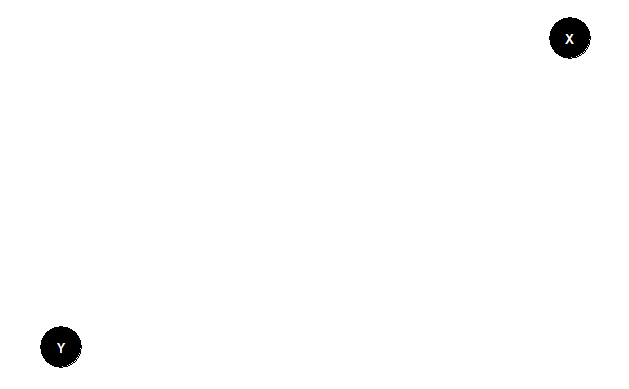

```r
library(dagitty)
library(ggdag)
dag0 <- dagify(
  X ~ X,
  Y ~ Y
)

ggdag(dag0)+ theme_dag()
```

Con la funzione `impliedConditionalIndependencies()` del pacchetto `dagitty`, possiamo visualizzare le indipendenze condizionali. In questo caso ci aspettiamo che X e Y siano indipendenti:

```r
impliedConditionalIndependencies(dag0)
```

```
X _||_ Y
```

infatti, X è condizionalmente indipendente da Y (e viceversa).

Se eseguo una regressione lineare, data l’indipendenza il coefficiente di X non sarà significativo:

```r
summary(
  lm(y ~ x, data = ind)
)
```

[output not shown]

cvd (come volevasi dimostare).

### 2 nodi dipendenti

Ripetiamo l’analisi usando 2 nodi dipendenti stavolta. Per creare dipendenza assegnamo alla media di Y i valori di X moltiplicati per una costante ( in questo caso 2). Così facendo genereremo dati con errore, ma con media doppia rispetto ad X.

```r
set.seed(100)

# genero due distribuzioni normali dipendenti:
# la media di y è pari a 2 volte la media di x

# prima genero x
dip <- data.frame(x = rnorm(n))

# poi genero y
dip$y <- rnorm(n, mean = 2*dip$x)

# restituisce i primi elementi del data-frame
head(dip)
```

|  | x | y |
| --- | --- | --- |
| 1 | -0.50219235 | -1.3373081 |
| 2 | 0.13153117 | 1.6261760 |
| 3 | -0.07891709 | -0.6269815 |
| 4 | 0.88678481 | 2.6164453 |
| 5 | 0.11697127 | -1.2240512 |
| 6 | 0.31863009 | 0.2369543 |

Plottiamo i dati:

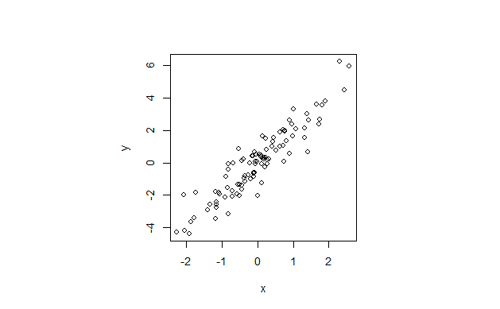

```r
par(pty = "s")
plot(y~x, data = dip)
```

si vede chiaramente una relazione di tipo lineare questa volta.

Il relativo DAg lo si può costruire e rappresentare con il seguente codice:

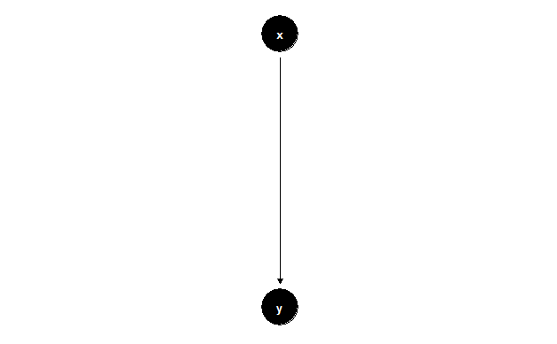

```r
dag1 <- dagify(
  y~x
)

# layout dispone i nodi in maniera particolare; vedremo alcuni esempi.
# "tree" dispone i dati in ordine grearchico, dalla causa più a monte
# alla conseguenza più a valle
ggdag(dag1, layout = "tree") +
  theme_dag()
```

Partendo dal DAG anche stavolta controlliamo le indipendenze condizionali:

```r
impliedConditionalIndependencies(dag1)
```

Nessun output. Vuol dire che non ci sono indipendenze condizionali! Vuol dire che tutti i nodi dipendono dagli altri.

Procediamo con la regressione lineare:

```r
summary(
  lm(y~x, data = dip)
  )
```

```
Call:
lm(formula = y ~ x, data = dip)

Residuals:
     Min       1Q   Median       3Q      Max
-2.05195 -0.43265 -0.07854  0.48583  1.93858

Coefficients:
            Estimate Std. Error t value Pr(>|t|)
(Intercept)  0.01145    0.07929   0.144    0.885
x            1.89463    0.07807  24.267   <2e-16 ***
---
Signif. codes:  0 ‘***’ 0.001 ‘**’ 0.01 ‘*’ 0.05 ‘.’ 0.1 ‘ ’ 1

Residual standard error: 0.7929 on 98 degrees of freedom
Multiple R-squared:  0.8573,    Adjusted R-squared:  0.8559
F-statistic: 588.9 on 1 and 98 DF,  p-value: < 2.2e-16
```

Il coefficiente di X in questo caso è significativo! DA notare la rimilarità con il valore che abbiamo imposto nel generare dati da y, ovvero 2. Infatti, noi nel generare dati abbiamo imposto che la media di Y sia il doppio della media di X, quindi $y=2\,x$ come ci ha restituito la regressione (a meno dell’errore). Controllare il valore e la significatività dei coefficienti sarà uno dei nostri modi per verificare se la stima di questi è corretta oppure è biased.

Per completezza plottiamo i dati con la linea di regressione:

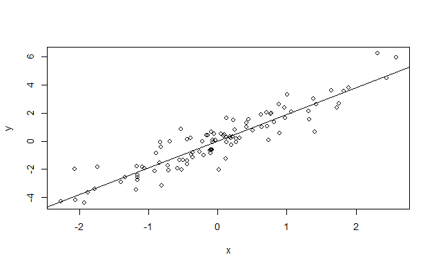

```r
plot(y ~ x, data = dip)
abline(lm(y~x, data = dip))
```

Bene, ora procediamo con gli elemental confounders.

## pipe

La pipe è la struttura a tre nodi in cui ogni variabile influenza la successiva causalmente.

Rappresentiamola con un DAG su R:

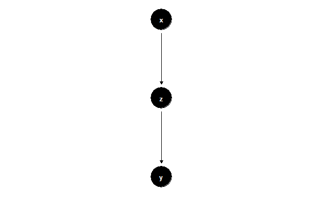

```r
dagpipe <- dagify(
  y~z,
  z~x
)

ggdag(dagpipe, layout = "tree") + theme_dag_blank()
```

Riassumiamo qui di seguito le indipendenze condizionali della pipe: $$
$$\begin{array}{ll}
Y \not\!\perp\!\!\!\perp X & \text{[x and y are assocaited]} \\
Y \perp \! \! \! \perp X|Z & \text{[x and y are not associated,
conditional on Z]}
\end{array}$$

$$ il che vuol dire che se facciamo una regressione lineare `y~x`, x avrà coefficiente significativo; se invece facciamo una regressione `y~x+z`, x avrà coefficiente non significativo, perchè il flusso associativo tra y e x sarà bloccato.

Verifichiamo le dipendenze condizionali con la funzione di R:

```r
impliedConditionalIndependencies(dagpipe)
```

```
x _||_ y | z
```

et voilà! NB: la funzione restituisce solo i casi in cui le variabili sono causalmente indipendenti, non gli altri casi.

Bene, testiamolo. Generiamo dei dati che seguono la struttura di una pipe:

```r
set.seed(2024) # riproducibilità

dfpipe <- data.frame(x = rnorm(n))
# la media dei valori di z dipende da x
dfpipe$z <- rnorm(n, mean = 2*dfpipe$x)
# la media dei valori di y dipende da z
dfpipe$y <- rnorm(n, mean = 3*dfpipe$z)

head(dfpipe) # restituisce le prime 6 righe del data-frame
```

|  | x | z | y |
| --- | --- | --- | --- |
| 1 | 0.9819694 | 1.9661283 | 7.898819 |
| 2 | 0.4687150 | 1.4127944 | 5.026788 |
| 3 | -0.1079713 | -0.9936852 | -2.791152 |
| 4 | -0.2128782 | -0.2203787 | -1.490562 |
| 5 | 1.1580985 | 3.3387417 | 10.974180 |
| 6 | 1.2923548 | 1.5746329 | 2.663712 |

Bene, ora eseguiamo due regressioni lineari, una con Z e l’altra senza e confrontiamo i risultati:

```r
lm(y~x, data = dfpipe) %>% summary()
```

```
Call:
lm(formula = y ~ x, data = dfpipe)

Residuals:
    Min      1Q  Median      3Q     Max
-9.5506 -2.0453 -0.0776  2.0752 10.0030

Coefficients:
            Estimate Std. Error t value Pr(>|t|)
(Intercept)   0.1180     0.2373   0.497    0.619
x             6.1449     0.2484  24.738   <2e-16 ***
---
Signif. codes:  0 ‘***’ 0.001 ‘**’ 0.01 ‘*’ 0.05 ‘.’ 0.1 ‘ ’ 1

Residual standard error: 3.34 on 198 degrees of freedom
Multiple R-squared:  0.7555,    Adjusted R-squared:  0.7543
F-statistic:   612 on 1 and 198 DF,  p-value: < 2.2e-16
```

```r
lm(y~x+z, data = dfpipe) %>% summary()
```

```
Call:
lm(formula = y ~ x + z, data = dfpipe)

Residuals:
    Min      1Q  Median      3Q     Max
-2.4879 -0.7388 -0.0643  0.6139  3.1629

Coefficients:
            Estimate Std. Error t value Pr(>|t|)
(Intercept)  0.10616    0.07074   1.501    0.135
x            0.05040    0.15417   0.327    0.744
z            2.98429    0.06622  45.069   <2e-16 ***
---
Signif. codes:  0 ‘***’ 0.001 ‘**’ 0.01 ‘*’ 0.05 ‘.’ 0.1 ‘ ’ 1

Residual standard error: 0.9958 on 197 degrees of freedom
Multiple R-squared:  0.9784,    Adjusted R-squared:  0.9782
F-statistic:  4459 on 2 and 197 DF,  p-value: < 2.2e-16
```

come ci aspettavamo includendo la variabile Z, X non è più significativo. Al contrario non includendolo otteniamo la stima causale di X su Y. Da notare come nel primo caso il coefficiente complessivo sia il prodotto delle costanti da noi inserite nella generazione dei dati; mentre nel secondo caso il coefficiente è pari a quello da noi inserito per generare i dati di Y da Z.

Proviamo ora a fare l’inverso, ovvero a spiegare X con Y, con e senza la’usilio di Z.

```r
lm(x~y, data = dfpipe) %>% summary()
```

```
Call:
lm(formula = x ~ y, data = dfpipe)

Residuals:
     Min       1Q   Median       3Q      Max
-1.26709 -0.29979 -0.06043  0.34703  1.60822

Coefficients:
            Estimate Std. Error t value Pr(>|t|)
(Intercept) -0.03688    0.03349  -1.101    0.272
y            0.12295    0.00497  24.738   <2e-16 ***
---
Signif. codes:  0 ‘***’ 0.001 ‘**’ 0.01 ‘*’ 0.05 ‘.’ 0.1 ‘ ’ 1

Residual standard error: 0.4725 on 198 degrees of freedom
Multiple R-squared:  0.7555,    Adjusted R-squared:  0.7543
F-statistic:   612 on 1 and 198 DF,  p-value: < 2.2e-16
```

```r
lm(x~y+z, data = dfpipe) %>% summary()
```

```
Call:
lm(formula = x ~ y + z, data = dfpipe)

Residuals:
     Min       1Q   Median       3Q      Max
-1.20760 -0.33024 -0.02773  0.35188  1.52680

Coefficients:
            Estimate Std. Error t value Pr(>|t|)
(Intercept) -0.02373    0.03282  -0.723 0.470508
y            0.01076    0.03291   0.327 0.744085
z            0.34440    0.09992   3.447 0.000693 ***
---
Signif. codes:  0 ‘***’ 0.001 ‘**’ 0.01 ‘*’ 0.05 ‘.’ 0.1 ‘ ’ 1

Residual standard error: 0.46 on 197 degrees of freedom
Multiple R-squared:  0.7694,    Adjusted R-squared:  0.7671
F-statistic: 328.7 on 2 and 197 DF,  p-value: < 2.2e-16
```

in questo caso Y si comporta esattamente come X: significativo senza Z, non significativo in presenza di Z. Questo ci sta ad indicare come è indifferente la direzione delle frecce nel DAG; se ho una pipe le indipendenze condizionali saranno le medesime.

Quindi già adesso abbiamo visto come la significatività dei coefficienti non sia per forza indice di causalità: un variabile significativa potrebbe essere una variabile conseguente alla variabile indipendente, oppure una variabile non significativa potrebbe essere una variabile a monte la cui associazione è bloccata dalla presenza di variabili di controllo intermedie.

## fork

La fork è quella struttura a tre nodi in cui Z è una causa comune sia di X che di Y.

Costruiamo il DAG:

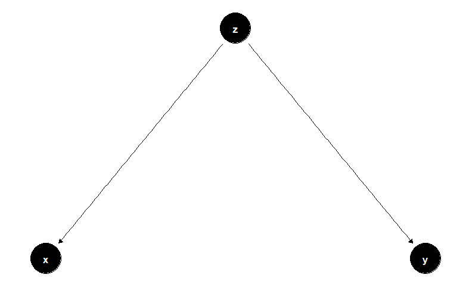

```r
dagfork <- dagify(
  x~z,
  y~z
)

ggdag(dagfork, layout = "tree") + theme_dag_blank()
```

Le indipendenze condizionali della fork sono: $$
$$\begin{array}{ll}
Y \not\!\perp\!\!\!\perp X & \text{[x and y are associated]} \\
Y \perp \! \! \! \perp X|Z & \text{[x and y are not associated,
conditional on Z]}
\end{array}$$

Testiamole:

```r
impliedConditionalIndependencies(dagfork)
```

```
x _||_ y | z
```

cvd.

Ora generiamo dati da una fork e vediamo se le condizioni vengono rispettate:

```r
set.seed(2024)
# genero valori di z
dffork <- data.frame(
  z =rnorm(n)
)
# genero valori di x e di y in relazione al valore di z
dffork$x <- rnorm(n, mean = 2*dffork$z)
dffork$y <- rnorm(n, mean = 3*dffork$z)
head(dffork)
```

|  | z | x | y |
| --- | --- | --- | --- |
| 1 | 0.9819694 | 1.9661283 | 4.9463427 |
| 2 | 0.4687150 | 1.4127944 | 2.1945494 |
| 3 | -0.1079713 | -0.9936852 | -0.1340103 |
| 4 | -0.2128782 | -0.2203787 | -1.4680608 |
| 5 | 1.1580985 | 3.3387417 | 4.4322505 |
| 6 | 1.2923548 | 1.5746329 | 1.8168778 |

Bene, ora eseguiamo due regressioni lineari (cercando di spiegare Y sempre grazie ad X), una con Z e l’altra senza; confrontiamo i risultati:

```r
lm(y~x, data = dffork) %>% summary()
```

```
Call:
lm(formula = y ~ x, data = dffork)

Residuals:
    Min      1Q  Median      3Q     Max
-4.4877 -1.1126 -0.0949  1.1144  4.4371

Coefficients:
            Estimate Std. Error t value Pr(>|t|)
(Intercept) -0.08644    0.10984  -0.787    0.432
x            1.27024    0.05033  25.239   <2e-16 ***
---
Signif. codes:  0 ‘***’ 0.001 ‘**’ 0.01 ‘*’ 0.05 ‘.’ 0.1 ‘ ’ 1

Residual standard error: 1.551 on 198 degrees of freedom
Multiple R-squared:  0.7629,    Adjusted R-squared:  0.7617
F-statistic:   637 on 1 and 198 DF,  p-value: < 2.2e-16
```

```r
lm(y~x+z, data = dffork) %>% summary()
```

```
Call:
lm(formula = y ~ x + z, data = dffork)

Residuals:
     Min       1Q   Median       3Q      Max
-2.26007 -0.72011 -0.02219  0.73746  2.17267

Coefficients:
            Estimate Std. Error t value Pr(>|t|)
(Intercept) -0.01857    0.06907  -0.269    0.788
x            0.10651    0.07371   1.445    0.150
z            2.74532    0.15710  17.475   <2e-16 ***
---
Signif. codes:  0 ‘***’ 0.001 ‘**’ 0.01 ‘*’ 0.05 ‘.’ 0.1 ‘ ’ 1

Residual standard error: 0.9739 on 197 degrees of freedom
Multiple R-squared:  0.907, Adjusted R-squared:  0.9061
F-statistic: 960.8 on 2 and 197 DF,  p-value: < 2.2e-16
```

esattamente come con la pipe nel primo caso X ha coefficiente significativo (associazione aperta), mentre nel secondo caso il coefficiente di X non è significativo (l’associazione è bloccata). Da notare che nel secondo caso il coefficiente di Z è simile al valore con cui abbiamo generato i dati.

Una funzione interessante che useremo anche nella prossima lezione è `ggdag_equivalent_dags()` restituisce i DAGs equivalenti (con le stesse indipendenze condizionali) ad un dato DAG in input . Proviamo ad inserire il DAG della fork:

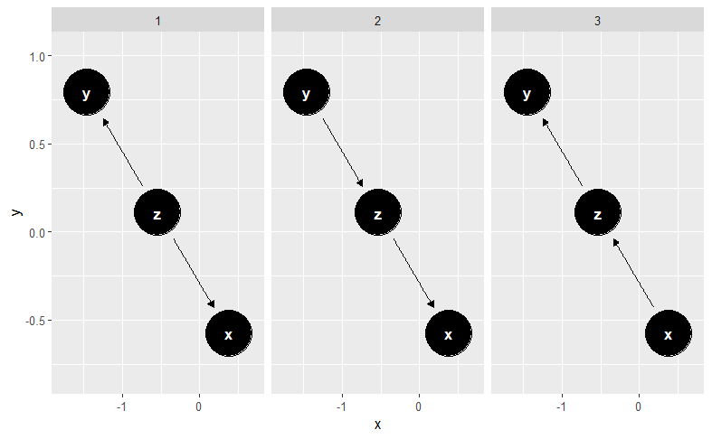

Ed ecco un’ulteriore prova che pipe e fork hanno le stesse indipendenze condizionali. In altre parole, senza conoscenze scientifiche pregresse e partendo dai soli dati, queste tre strutture sono identiche statisticamente.

## collider

Il collider è quella struttura a 3 nodi in cui Z è una conseguenza comune di X ed Y.

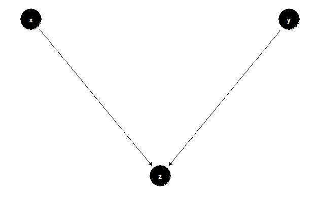

```r
dagcoll <- dagify(
  z~x+y,
  # possiamo anche inserire le coordinate dei nodi a piacere
  coords = list(
    x = c(x = 0, z = 1, y = 2), # coord di x per i tre nodi
    y = c(x = 1, z = 0, y = 1) # coord di y per i tre nodi
                  )
)

ggdag(dagcoll) + theme_dag_blank()
```

Le indipendenze condizionali del collider sono le seguenti:
$$\begin{array}{ll}
Y \!\perp\!\!\!\perp X & \text{[x and y are not associated]} \\
Y \not\!\perp \! \! \! \perp X|Z & \text{[x and y are associated,
conditional on Z]}
\end{array}$$
Testiamole:

```r
impliedConditionalIndependencies(dagcoll)
```

```
x _||_ y
```

X e Y sono indipendenti solo se **non** condizionati per Z.

Generiamo dati e testiamo con i numeri:

```r
set.seed(2024)
# genero x e y da due distribuzioni normali indipendenti
dfcoll <- data.frame(x = rnorm(n),
                     y = rnorm(n))
# genero z con media che dipende in parti uguali sia da x che da y
dfcoll$z <- rnorm(n, mean = dfcoll$x+dfcoll$y)
head(dfcoll)
```

|  | x | y | z |
| --- | --- | --- | --- |
| 1 | 0.9819694 | 0.002189461 | 2.9845934 |
| 2 | 0.4687150 | 0.475364335 | 1.7324836 |
| 3 | -0.1079713 | -0.777742496 | -0.6958101 |
| 4 | -0.2128782 | 0.205377675 | -0.8369268 |
| 5 | 1.1580985 | 1.022544742 | 3.1385984 |
| 6 | 1.2923548 | -1.010076810 | -1.7779087 |

Ora procediamo nuovamente eseguendo due regressioni lineari stratificando o meno per la variabile Z e confrontiamo i risultati.

```r
lm(y~x, data = dfcoll) %>% summary()
```

```
Call:
lm(formula = y ~ x, data = dfcoll)

Residuals:
     Min       1Q   Median       3Q      Max
-2.78905 -0.62201  0.00958  0.55898  2.81551

Coefficients:
            Estimate Std. Error t value Pr(>|t|)
(Intercept)  0.06853    0.06641   1.032    0.303
x           -0.07440    0.06493  -1.146    0.253

Residual standard error: 0.9389 on 198 degrees of freedom
Multiple R-squared:  0.006587,  Adjusted R-squared:  0.00157
F-statistic: 1.313 on 1 and 198 DF,  p-value: 0.2532
```

```r
lm(y~x+z, data = dfcoll) %>% summary()
```

```
Call:
lm(formula = y ~ x + z, data = dfcoll)

Residuals:
     Min       1Q   Median       3Q      Max
-1.81555 -0.45049 -0.00793  0.46326  1.73955

Coefficients:
            Estimate Std. Error t value Pr(>|t|)
(Intercept)  0.04092    0.04551   0.899     0.37
x           -0.49682    0.05261  -9.443   <2e-16 ***
z            0.48221    0.03212  15.012   <2e-16 ***
---
Signif. codes:  0 ‘***’ 0.001 ‘**’ 0.01 ‘*’ 0.05 ‘.’ 0.1 ‘ ’ 1

Residual standard error: 0.6429 on 197 degrees of freedom
Multiple R-squared:  0.5366,    Adjusted R-squared:  0.5319
F-statistic: 114.1 on 2 and 197 DF,  p-value: < 2.2e-16
```

In assenza di Z, X non ha coefficiente significativo, infatti, l’associazione tra X e Y è bloccata. Al contratio, sia X che Z sono significativi (!!!) includendo Z come covariata, perché il flusso associativo in questo caso è aperto.

## considerazioni sugli elemental confounders

In conclusione, abbiamo dimostrato come le regressioni lineari non misurino la causalità tra le variabili, ma la loro associazione e abbiamo visto come questa vari in base alle variabili incluse o meno nella regressione. Abbiamo visto come la significatività di un coefficiente non abbia nulla a che fare con un rapporto causale tra le variabili; nel caso di fork e collider ad esempio il coefficiente di X può essere significativo, ma non c’è nessun rapporto causale che colleghi X a Y!

Quindi, pensate a cosa potrebbe succedere se in una regressione lineare multivariabile fossero usate tutte le variabili misurate come predittori indipendentemente dal loro rapporto causale; si aprirebbero e chiuderebbero una serie di flussi associativi di cui, in assenza di un DAG, non siamo a conoscenza restituendoci una stima dei coefficienti totalmente slegata da rapporti di tipo causale. Nella prossima lezione avremo modo di vedere questo effetto.

Pensare ad un DAG prima di effettuare qualsiasi tipo di analisi ci consente di ragionare sui flussi associativi, selezionare le variabili da introdurre come covariate e ad evitare bias nella stima dei coefficienti. Inoltre, possono anche aiutarci nel design sperimentale a *selesionare* quali variabili raccogliere. Nella prossima lezione vedremo meglio come. Nel frattempo vediamo alcuni esempi di situazioni che potrebbero essere reali.

## Esempi

NB: gli esempi sono semplificati e prevedono tutti una relazione di tipo lineare.

### Funghi, piante e trattamento

Alcuni funghi possono essere dannosi per le piante e inibirne lo sviluppo. è stato preso gruppo di 100 piante della stessa specie. La metà sono state trattate con un nuovo trattamento antifungino e, al momento del trattamento, ne è stata misurata l’altezza (h0). Poi sono state incubate per un certo periodo di tempo. Al termine dell’esperimento è stata nuovamente misurata l’altezza (h1) di ogni pianta ed è stato valutato se si fossero sviluppati anche i funghi dannosi o meno. I dati sono stati raccolti nel seguente data frame:

| h0 | h1 | treatment | fungus |
| --- | --- | --- | --- |
| 11.963939 | 11.826500 | 0 | 1 |
| 10.937430 | 15.893773 | 0 | 0 |
| 9.784057 | 13.177588 | 0 | 1 |
| 9.574244 | 15.818684 | 0 | 0 |
| 12.316197 | 12.548984 | 0 | 1 |
| 12.584710 | 14.633195 | 0 | 0 |
| 11.069294 | 12.398533 | 0 | 1 |
| 9.745931 | 14.440169 | 0 | 0 |
| 7.550249 | 11.837715 | 0 | 0 |
| 7.757297 | 9.049545 | 0 | 1 |

[output cut: 90 more lines]

in cui `h0` e `h1` sono rispettivamente l’altezza iniziale e finale, `treatment` indica se le piante sono state trattate (`1`) oppure no (`0`) e `fungus` indica se si è sviluppato (`1`) o meno (`0`) il micelio del fungo.

è stata quindi fatta una regressione lineare con *tutte* le variabili misurate:

```r
lm(h1~h0 + treatment + fungus, data = fungus) %>% summary()
```

```
Call:
lm(formula = h1 ~ h0 + treatment + fungus, data = fungus)

Residuals:
     Min       1Q   Median       3Q      Max
-2.85715 -0.59537 -0.02372  0.62333  2.21295

Coefficients:
            Estimate Std. Error t value Pr(>|t|)
(Intercept)  6.61956    0.47174  14.032   <2e-16 ***
h0           0.86381    0.04499  19.199   <2e-16 ***
treatment   -0.16291    0.19317  -0.843    0.401
fungus      -4.10071    0.22022 -18.621   <2e-16 ***
---
Signif. codes:  0 ‘***’ 0.001 ‘**’ 0.01 ‘*’ 0.05 ‘.’ 0.1 ‘ ’ 1

Residual standard error: 0.9152 on 96 degrees of freedom
Multiple R-squared:  0.8876,    Adjusted R-squared:  0.8841
F-statistic: 252.7 on 3 and 96 DF,  p-value: < 2.2e-16
```

dalla regressione si *dedurrebbe* che l’altezza iniziale gioca un ruolo rilevante nel predirre l’altezza finale insieme alla presenza o meno del fungo. Notiamo inoltre che l’altezza iniziale ha coefficiente positivo, il che vuol dire che all’aumentare dell’altezza iniziale è ragionevole aspettarsi un’aumento dell’altezza finale (più la pianta è alta al tempo 0, più sarà alta al termine dell’esperimento); mentre, il coefficiente sulla presenza del fungo è negativo, ad indicare come questo inibisca la crescita della pianta. Il trattamento tuttavia sembra non avere alcun effetto, sulla crescita.

Ma ne siamo sicuri? Controlliamo i dati. Faccio un grafico riportando l’altezza finale sulle ordinate e lo stato del trattamento sulle ascisse. Per visualizzare meglio la distribuzione delle altezze utilizzo `ggplot` e la funzione `geom_violin()` che essenzialmente rappresenta come sono distriuiti i valori della variabile; le zone di maggiore larghezza hanno una densità di punti maggiore. `geom_violin()` è un’alternativa al boxplot.

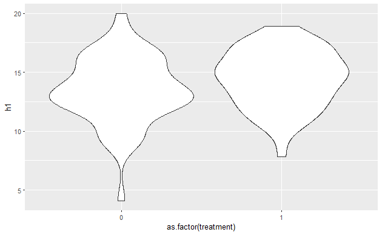

nonostante non sia particolarmente netta (spoiler, nei dati sperimentali non lo è quasi mai), vi è una differenza di distribuzione tra i due gruppi. In particolar modo la “*pancia*” del trattamento è spostata più in alto rispetto alla controparte e valori estremamente bassi sono esclusi. Possiamo spiegare il fatto contando anche che il trattamento non funziona al 100%, ci sono alcuni casi in cui il fungo si è sviluppato con il trattamento; allo stesso tempo ci sono casi in cui il fungo non si è sviluppato senza trattamento.

Quindi osservando i dati possiamo dire che a occhio il tratamento ha funzionato. Allora cosa c’è che non va? Pensiamo al DAG del fenomeno che stiamo analizzando. Sappiamo che l’altezza finale sarà sicuramente influenzata dall’altezza inizale e dalla presenza del fungo. Sappiamo che il trattamento influisce sulla presenza del fungo; inoltre, dati in letteratura ci mostrano che il trattamento non ha influenza sulla crescita della pianta pianta. Da queste informazioni possiamo costruire il DAG.

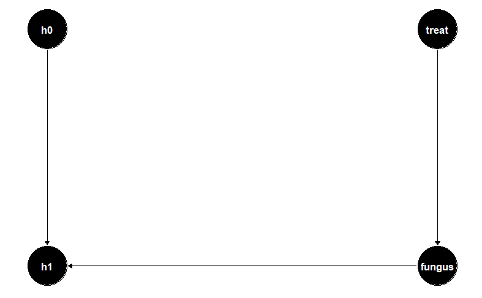

```r
dag_fungus <- dagify(
  h1 ~ h0 + fungus,
  fungus ~ treat

)

ggdag(dag_fungus, node_size = 20, layout = "tree") + theme_dag()
```

notiamo che h1 e trattamento sono collegati da una pipe. Introducendo quindi la variabile fungo abbiamo bloccato il canale associativo tra le due variabili, ecco perché il coefficiente non è signficiativo.

Riproviamo evitando di inserire la presenza del fungo:

```r
lm(h1~h0 + treatment , data = fungus) %>% summary()
```

```
Call:
lm(formula = h1 ~ h0 + treatment, data = fungus)

Residuals:
    Min      1Q  Median      3Q     Max
-4.2379 -1.3624  0.4397  1.3783  3.8277

Coefficients:
            Estimate Std. Error t value Pr(>|t|)
(Intercept)   4.8031     0.9860   4.871 4.32e-06 ***
h0            0.8817     0.0961   9.175 8.12e-15 ***
treatment     0.9860     0.3911   2.521   0.0133 *
---
Signif. codes:  0 ‘***’ 0.001 ‘**’ 0.01 ‘*’ 0.05 ‘.’ 0.1 ‘ ’ 1

Residual standard error: 1.955 on 97 degrees of freedom
Multiple R-squared:  0.4816,    Adjusted R-squared:  0.4709
F-statistic: 45.06 on 2 and 97 DF,  p-value: 1.45e-14
```

trattamento significativo! Trattare complessivamente aiuta ad aumentare (coefficiente positivo), l’altezza finale delle piante.

Ma `h0` che influenza ha invece? Proviamo a rimuoverlo:

```r
lm(h1~ treatment , data = fungus) %>% summary()
```

```
Call:
lm(formula = h1 ~ treatment, data = fungus)

Residuals:
    Min      1Q  Median      3Q     Max
-9.4158 -1.5759  0.1552  2.2111  6.5244

Coefficients:
            Estimate Std. Error t value Pr(>|t|)
(Intercept)  13.4867     0.3760  35.871   <2e-16 ***
treatment     0.9531     0.5317   1.792   0.0762 .
---
Signif. codes:  0 ‘***’ 0.001 ‘**’ 0.01 ‘*’ 0.05 ‘.’ 0.1 ‘ ’ 1

Residual standard error: 2.659 on 98 degrees of freedom
Multiple R-squared:  0.03174,   Adjusted R-squared:  0.02186
F-statistic: 3.213 on 1 and 98 DF,  p-value: 0.07615
```

il trattamento ha perso significatività. `h0` è un **descendant**, un collegamento terminale alle variabili di interesse o a variabili di controllo intermedie. I descendand sono po’ come dei jolly e possono aiutare la stima dei coefficienti come possono aumentarne il bias o non avere alcun effetto. In questo caso è una causa della variabile di interesse `h1` e la sua presenza nella regressione è favorevole perché ci consente di stimare con più precisione l’effetto del trattamento.

NB: se `h0` fosse stata una conseguenza di `h1`, sarebbe stato un descendant malevolo e la sua presenza avrebbe alterato la corretta stima dell’effetto del trattanento. Impostare un DAG è utile anche per queste cose.

### umbrellas and car creashes

Un recente studio ha fatto scalpore perché affermava che ci fosse un rapporto di causa-effetto tra incidenti stradali e il numero di ombrelli presenti su strada. Gli autori insistevano nell’affermare che gli ombrelli per gli automobilisti fossero come i velli rossi per i tori, aumentandone l’aggressivita e l’avventatezza. I dati sono riportati nel data-frame umbrellas:

|  | rain | crashes | umbrellas |
| --- | --- | --- | --- |
| 1 | 0.9819694 | 125 | 2991 |
| 2 | 0.4687150 | 62 | 1468 |
| 3 | 0.0000000 | 18 | 46 |
| 4 | 0.0000000 | 25 | 41 |
| 5 | 1.1580985 | 153 | 3490 |
| 6 | 1.2923548 | 154 | 3941 |

dove `crashes` indica il numero di incidenti, `umbrellas` indica il numero di ombrelli osservati dai ricercatori quel giorno e `rain` è una scala arbitraria che indica quanto pioveva quel giorno (0 no pioggia, >0 pioggia di intensità correlata al valore).

Gli autori nel paper hanno fatto la seguente regressione lineare ottenendo un coefficiente significativo:

```r
lm(crashes~umbrellas, data = umbrellas) %>% summary()
```

```
Call:
lm(formula = crashes ~ umbrellas, data = umbrellas)

Residuals:
    Min      1Q  Median      3Q     Max
-25.961  -4.434  -0.282   4.103  34.650

Coefficients:
             Estimate Std. Error t value Pr(>|t|)
(Intercept) 1.833e+01  5.664e-01   32.37   <2e-16 ***
umbrellas   3.331e-02  2.679e-04  124.33   <2e-16 ***
---
Signif. codes:  0 ‘***’ 0.001 ‘**’ 0.01 ‘*’ 0.05 ‘.’ 0.1 ‘ ’ 1

Residual standard error: 7.782 on 298 degrees of freedom
Multiple R-squared:  0.9811,    Adjusted R-squared:  0.981
F-statistic: 1.546e+04 on 1 and 298 DF,  p-value: < 2.2e-16
```

sembrerebbe quindi che la presenza degli ombrelli per strada aumenti significativamente il numero di incidenti…

Pensiamo al DAG di questo fenomeno: sappiamo sicuramente che la piogia causa l’aumento sia del numero di ombrelli per strada per ripararsi dalla pioggia, sia il numero di incidenti per ridotta visibilità, ecc.

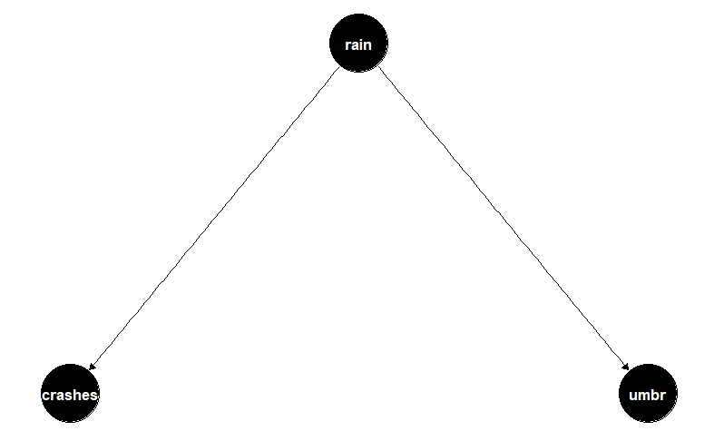

```r
dag_rain <- dagify(
  crashes ~ rain,
  umbr ~ rain
)

ggdag(dag_rain, layout = "tree", node_size = 20) + theme_dag()
```

è decisamente una fork. Quindi Il flusso tra `crashes` e `umbrellas` è aperto se non stratifichiamo per `rain`. Stratificando per `rain` l’effetto dovrebbe scomprarire:

```r
lm(crashes~umbrellas +rain, data = umbrellas) %>% summary()
```

```
Call:
lm(formula = crashes ~ umbrellas + rain, data = umbrellas)

Residuals:
     Min       1Q   Median       3Q      Max
-25.3799  -4.4965  -0.0404   4.0647  30.6898

Coefficients:
             Estimate Std. Error t value Pr(>|t|)
(Intercept)  20.73844    1.03616  20.015  < 2e-16 ***
umbrellas    -0.01501    0.01751  -0.857  0.39206
rain        145.22126   52.63540   2.759  0.00616 **
---
Signif. codes:  0 ‘***’ 0.001 ‘**’ 0.01 ‘*’ 0.05 ‘.’ 0.1 ‘ ’ 1

Residual standard error: 7.697 on 297 degrees of freedom
Multiple R-squared:  0.9816,    Adjusted R-squared:  0.9814
F-statistic:  7904 on 2 and 297 DF,  p-value: < 2.2e-16
```

e infatti il numero di ombrelli non ha più coefficiente significativo. Inviamo agli autori la nostra analisi e il paper viene ritrattato.

### covid, fumo e tosse

I DAG possono essere utili anche per evitare bias negli studi clinici. Un esempio è riportato dal seguente dataset dove sono stati selezionati 300 pazienti ed è stato verificato se avessero contratto o meno il covid (`covid`, 1=Sì, 0=No), se soffrissero di problemi respiratori (`RespProb`, scala 0-10 per gravità) e quanti pacchetti di sigarette consumassero al giorno (`packs`):

| packs | covid | RespProb |
| --- | --- | --- |
| 1 | 1 | 2 |
| 1 | 1 | 4 |
| 0 | 0 | 0 |
| 0 | 1 | 4 |
| 2 | 0 | 2 |
| 2 | 1 | 4 |
| 1 | 1 | 5 |
| 0 | 0 | 0 |
| 2 | 1 | 2 |
| 2 | 1 | 5 |

[output cut: 290 more lines]

si vuole vedere se il fumo ha impattato sull’a contrazione’incidenza del covid; viene fatta quindi una regressione lineare con tutte le variabili:

```r
lm(covid ~ RespProb + packs, data = smoke) %>% summary()
```

```
Call:
lm(formula = covid ~ RespProb + packs, data = smoke)

Residuals:
     Min       1Q   Median       3Q      Max
-0.87105 -0.20069 -0.05453  0.23377  0.84065

Coefficients:
            Estimate Std. Error t value Pr(>|t|)
(Intercept)  0.19315    0.03339   5.785 1.84e-08 ***
RespProb     0.19103    0.00978  19.533  < 2e-16 ***
packs       -0.13862    0.02176  -6.372 7.11e-10 ***
---
Signif. codes:  0 ‘***’ 0.001 ‘**’ 0.01 ‘*’ 0.05 ‘.’ 0.1 ‘ ’ 1

Residual standard error: 0.3261 on 297 degrees of freedom
Multiple R-squared:  0.5687,    Adjusted R-squared:  0.5658
F-statistic: 195.8 on 2 and 297 DF,  p-value: < 2.2e-16
```

tutti i coefficienti sono significativi. Dalla regressione sembrerebbe che i problemi repsiratori impattano positivamente sulla contrazione del covid (coefficiente positivo), ma al contrario dalla regressione sembrerebbe che si riduca il rischio di contrarre il covid all’aumentare dei pacchetti di sigarette consumati.

Come mai? Costruiamo il DAG. è ragionevole pensare che il fumo indebolisca le difese delle vie respiratorie e quindi abbia un impatto sulla contrazione del covid. Possiamo inoltre dire che i problemi respiratori sono frutto sia del numero di pacchetti consumati, sia del fatto di avere o meno contratto il covid (il cosiddetto long-covid). Pertanto un possibile DAG potrebbe essere questo:

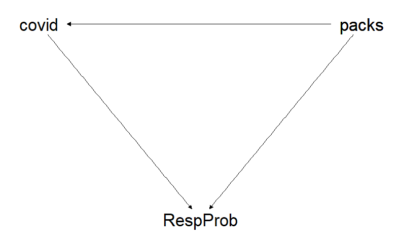

```r
dag_covid <- dagify(
  RespProb ~ covid + packs,
  covid ~ packs,
  coords = list(
    x = c(covid = 0, RespProb = 1, packs = 2),
    y = c(covid = 1, RespProb = 0, packs = 1)
  )
)

ggdag_classic(dag_covid) + # modo alternativo per plottare un dag
  theme_dag()
```

i problemi respiratori fungono da collider in questo caso, pertanto stratificando per il collider abbiamo aperto un’altra via di associazione tra covid e packs, il che potrebbe spiegare lo strano risultato che abbiamo ottenuto. Ripetiamo rimuovendo i problemi respiratori come covariata:

```r
lm(covid ~  packs, data = smoke) %>% summary()
```

```
Call:
lm(formula = covid ~ packs, data = smoke)

Residuals:
    Min      1Q  Median      3Q     Max
-0.8103 -0.5663  0.3727  0.4337  0.4947

Coefficients:
            Estimate Std. Error t value Pr(>|t|)
(Intercept)  0.50529    0.04424  11.422   <2e-16 ***
packs        0.06101    0.02898   2.105   0.0361 *
---
Signif. codes:  0 ‘***’ 0.001 ‘**’ 0.01 ‘*’ 0.05 ‘.’ 0.1 ‘ ’ 1

Residual standard error: 0.4921 on 298 degrees of freedom
Multiple R-squared:  0.01465,   Adjusted R-squared:  0.01135
F-statistic: 4.431 on 1 and 298 DF,  p-value: 0.03612
```

in questo caso il coefficiente è significativo e positivo, ci sta ad indicare che il numero di pacchetti consumati aumenta il rischio di contrarre il covid, come ci aspettavamo.

Da notare che la probabilità associata è ridotta nonosante il dato è corretto. Questo sottolinea ancora una volta come la significatività non debba essere intrepretata ciecamente come metrica per la causalità dei fenomeni.

# Backdoor path, adjustment sets ed effetti

## Backdoor paths e ajdustment set

Essenzialmente il metodo del **backdoor path** ci consente di chiudere tutti i percorsi non causali che portano la nostra exposure (X) alla nosta outcome (Y), consentendoci di ottenere una stima causale non distorta di X. Il metodo si compone di tre punti:

1. Elencare tutti i percorsi (causali e non) che collegano le due varabili. Tutti i percorsi che hanno frecce che puntano su X sono backdoor path e vanno chiusi.
2. Per ogni percorso valutare se risulta aperto o chiuso di default e identificare le possibili variabili che chiuderebbero il percorso.
3. Dal punto precedente selezionare un gruppo di variabili che chiuda tutti i backdoor paths.

Il gruppo di suddette variabili è definito **adjustment set**. Sono possibili più adjustment set per uno stesso DAG.

Costruiamo un DAG un po’ più complesso per capire meglio come funzionano il backdoor path e gli adjustment set:

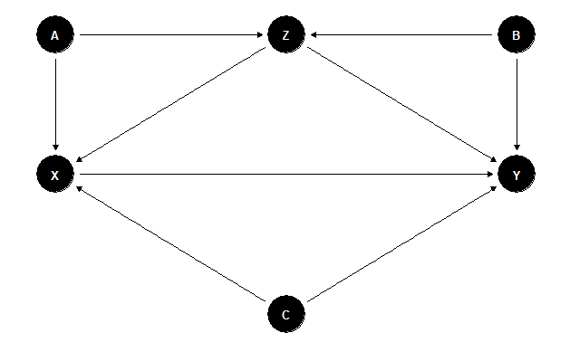

```r
dag2 <- dagify(
  Y ~ X+Z+C+B,
  Z ~ A+B,
  X ~ A+C+Z,
    coords = list(
    x = c(X = 0, Y = 2, A = 0, C = 1, Z = 1, B = 2),
    y = c(X = 0, Y = 0, A = 1, C = -1, Z = 1, B = 1)
  )
)

ggdag(dag2) + theme_dag()
```

Nel dichiarare il nostro DAG con la funzione `dagify()` possiamo aggiungere anche informazioni sullo stato delle variabili, ovvero qual è la nostra exposure (il nostro trattamento, X) e la nostra outcome (la nostra variabile di interesse, Y) e quali sono le variabili latent (non misurate, le vedremo dopo). Quindi ora costruiamo lo stesso DAG indicando che vogliamo scoprire che influenza ha X (exposure) sulla variabile Y (outcome). Lo possiamo indicare così:

```r
dag2 <- dagify(
  Y ~ X+Z+C+B,
  Z ~ A+B,
  X ~ A+C+Z,
  exposure = "X", # definisco la X (trattamento)
  outcome = "Y",  # definisco la Y (variabile dipendente)
    coords = list(
    x = c(X = 0, Y = 2, A = 0, C = 1, Z = 1, B = 2),
    y = c(X = 0, Y = 0, A = 1, C = -1, Z = 1, B = 1)
  )
)
```

per visualizzare anche lo stato delle variabili dobbiamo usare la funzione `ggdag_status()`:

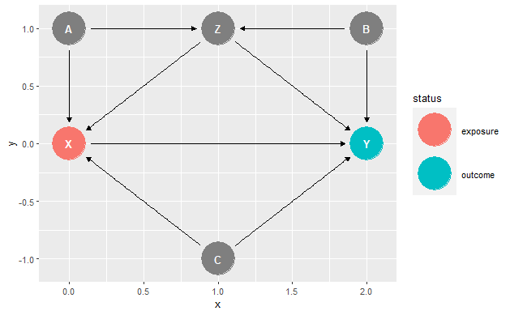

```r
ggdag_status(dag2)
```

Ora X ed Y sono indicate a colori, con la legenda a fianco. Tutte le altre variabili sono le *variabili di controllo* che possono essere incluse o meno per chiudere i backdoor paths.

Possiamo anche vedere tutti i percorsi che collegano le nostre due variabili con la funzione e se sono aperto o meno con la funzione:

```r
paths(dag2) %>% as.data.frame()
```

[output not shown]

questo grafico indica i percorsi aperti di default: vuol dire che se io facessi una semplice regressione `y~x` senza includere alcuna covariata, i percorsi sarebbero chiusi o aperti come indicato nel data-frame.

Possiamo visualizzare i pathway *aperti* con `ggdag_paths()` (non c’è la possibilità di vedere i pathway chiusi…):

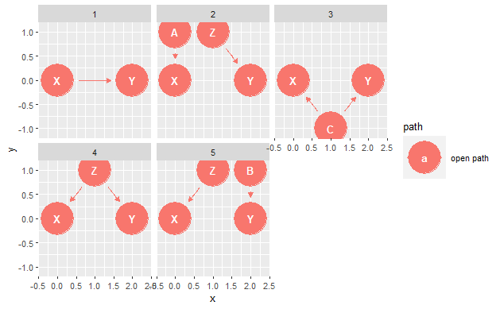

```r
ggdag_paths(dag2)
```

notiamo che nel grafico i percorsi dal 2 al 5 sono backdoor paths. Per ottenere una corretta stima dell’influenza di X su Y dovremmo stratisicare per variabili che chiudano questi percorsi. Nel caso di 3 possiamo stratificare per C, mentre ne caso di 4 potremmo stratificare per Z. Stratificando per Z dovremmo anche chiudere i path 2 e 5. Proviamo a vedere cosa succede se stratifichiamo per C e per Z con la funzione `ggdag_adjust()`:

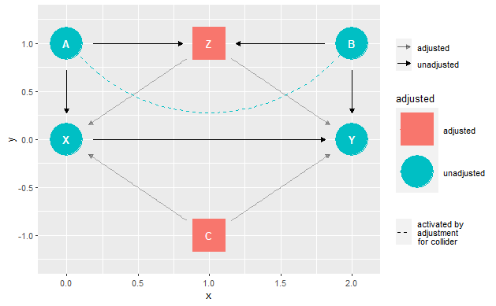

```r
ggdag_adjust(dag2,  var = c("C", "Z"))
```

Z funge da collider tra A e B. Stratificando per Z abbiamo chiuso i percorsi 2, 4 e 5, ma al contempo abbiamo aperto (linee tratteggiate) il collider e ora il flusso associativo X-A-Z-B-Y è aperto. Per chiudere Quel path dovremmo stratificare per A, per B o per entrambi. La scelta migliore è stratificare per B (è più vicino alla variabile dipendente).

Riproviamo:

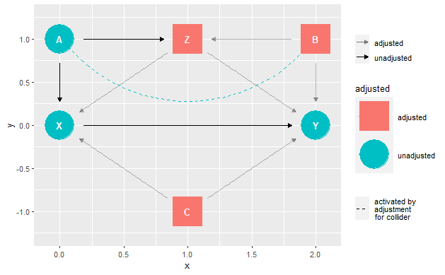

sebbene nel grafico A e B siano ancora associati, stratidicare per B blocca la via per Y (freccia grigia) bloccando il flusso associativo. Quindi gli unici path aperti sono quelli che collegano causalmente X con Y. Testiamolo con `ggdag_paths()` che ricordo mostra solo i pathway aperti tra X e Y:

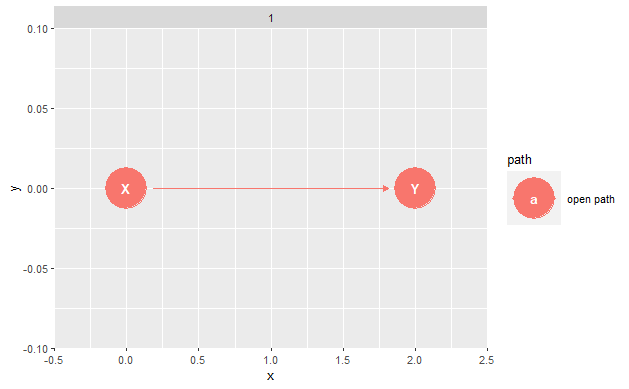

cvd.

Quindi possiamo dire che {B, C, Z} è un adjustment set del dag. Verifichiamolo con la funzione `ggdag_adjustment_set()`

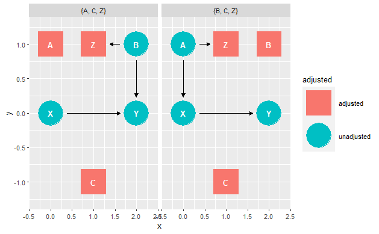

```r
ggdag_adjustment_set(dag2)
```

`ggdag` è d’accordo con noi; inoltre, ci fornisce anche un altro adjustment set. Infatti, possiamo anche stratificare per A al posto di B volendo, ma è meglio usare sempre la variabile più vicino alla nostra outcome se abbiamo possibilità di scegliere.

Ma cosa succederebbe se Z fosse una variabile non-misurata? vediamo:

```
Avvertimento: Failed to close backdoor paths. Common reasons include:
            * graph is not acyclic
            * backdoor paths are not closeable with given set of variables
            * necessary variables are unmeasured (latent)
```

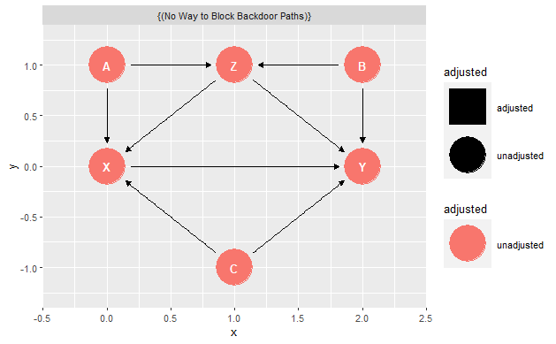

```r
ggdag_adjustment_set(dag2)
```

R ci restituisce un messaggio di warning che ci dice che non è stato possibile chiudere tutti i backdoor paths. Se non conoscessimo il valore di Z, per noi sarebbe possibile ottenere solo una stima distorta dell’effetto di X su Y.

## Effetti totali e diretti & coefficienti

Prendiamo in considerazione un DAG più semplice:

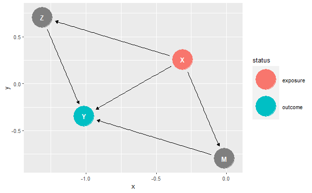

```r
dag4 <- dagify(
  Y~X+M+Z,
  Z~X,
  M~X,
  exposure = "X",
  outcome = "Y"
)
ggdag_status(dag4)
```

abbiamo due pipe e un collegamento diretto tra X e Y. Tutti questi rapporti sono causali. Vediamo gli adjustment set:

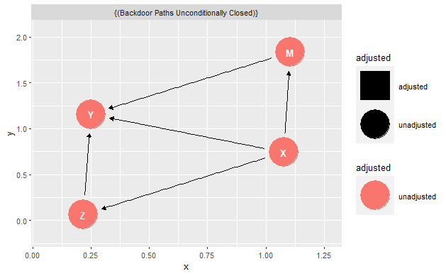

R ci dice che i backdoor path sono sempre chiusi, infatti non abbiamo frecce rivolte verso X, pertanto non dobbiamo condizionare per nessuna variabile. Tuttavia noi stiamo in questo momento guardando gli **effetti totali** che la variabile X ha sulla variabile Y, quindi stiamo tenendo conto anche degli effetti mediati dalle variabili Z e M. Tuttavia possiamo chiedere ad R anche quali siano gli adjustment set per vedere solo l’**effetto diretto** che la variabile X ha su Y:

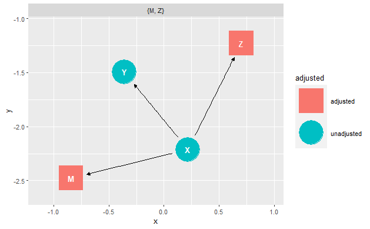

in questo caso R ci dice che dobiamo condizionare sia per Z che per M, bloccando il flusso associativo mediato da queste due variabili verso Y. Potremmo essere interessati anche a rimuovere solo una delle due variabili, per studiare l’effetto diretto e quello mediato ad esempio da M. In questo caso R non ha una funzione pronta, ma possiamo verificare che il nostro adjustment set sia corretto sempre con la funzione `ggdag_adjust()`:

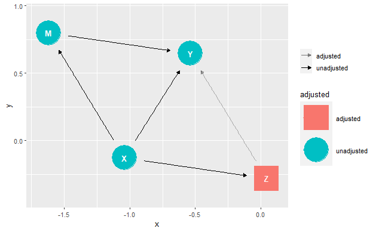

il path di Z è bloccato e quindi ci consente di vedere l’influenza diretta di X più quella mediata da M.

E se io volessi spiegare solo l’effetto di Z invece che di X? Posso cambiare sia l’exposure e l’outcome nelle funzioni:

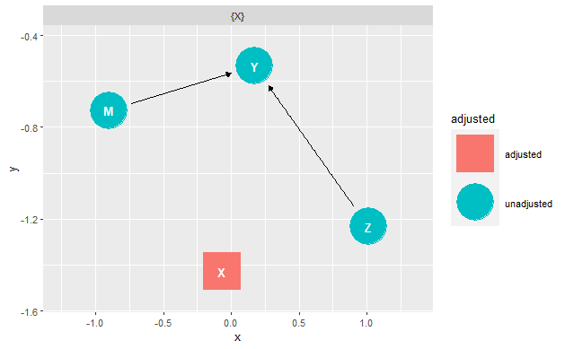

dovrei stratificare per X, ottenendo il set di covariate {X, Z}. Questo set di covariate sono le stesse dell’esempio precedente, ad indicare come mentre il coefficiente di X spiega l’influenza complessiva di X e M, il coefficiente di Z indica l’effetto diretto di Z su Y.

Tutti i coefficienti in base alle altre covariate utilizzate possono avere significati diversi. Possono rappresentari veri e propri effetti causali, totali, parziali o diretti, come possono non aver alcun significato. Infatti, spesso in DAG complessi una covariata viene aggiunta solo per chiudere flussi associativi, non perché il suo coefficiente abbia significato descrittivo del fenomeno (anche se significativo).

## Esempio: ancora piante e funghi

Riprendiamo l’esempio di prima dei trattamenti antifungini. è stato scoperto un nuovo trattamento che sembra performare meglio del primo. I dati sono contenuti nel data-frame `fungus1`. Stavolta prima di addentrarci nell’analisi costruiamo il DAG. Differentemente dall’altra volta in questo caso si suppone che il trattamento abbia un’influenza sulla crescita della pianta.

Pertanto il DAG diventa:

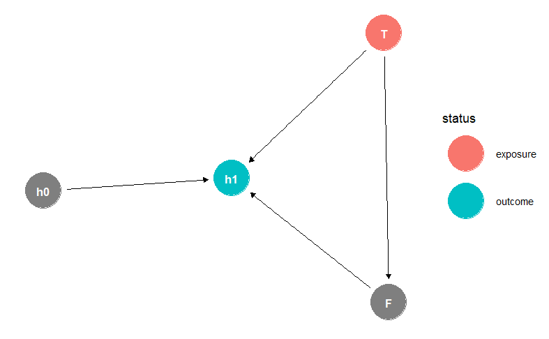

In questo caso treatment (`T`) è l’exposure perché siamo interessati a vedere come influenza l’altezza finale (`h1`) che è la nostra outcome.

Vediamo i percorsi possibili che collegano la nostra exposure alla nostra outcome:

| paths | open |
| --- | --- |
| T -> F -> h1 | TRUE |
| T -> h1 | TRUE |

Ce ne sono due ed entrambi sono aperti per default (significa che se eseguo una regressione lineare `h1~T`, i flussi associativi di entrambi i path sono aperti e influenzano il valroe del coefficiente di `T`). Tra l’altro sono entrambi path causali: una causa diretta ed una pipe.

Ora vediamo che faccia hanno i dati:

|  | h0 | h1 | treatment | fungus |
| --- | --- | --- | --- | --- |
| 1 | 11.963939 | 11.82650 | 0 | 1 |
| 2 | 10.937430 | 15.89377 | 0 | 0 |
| 3 | 9.784057 | 13.17759 | 0 | 1 |
| 4 | 9.574244 | 15.81868 | 0 | 0 |
| 5 | 12.316197 | 12.54898 | 0 | 1 |
| 6 | 12.584710 | 14.63319 | 0 | 0 |

sono strutturati esattamente come l’esempio precedente.

### effetti totali e diretti del trattamento

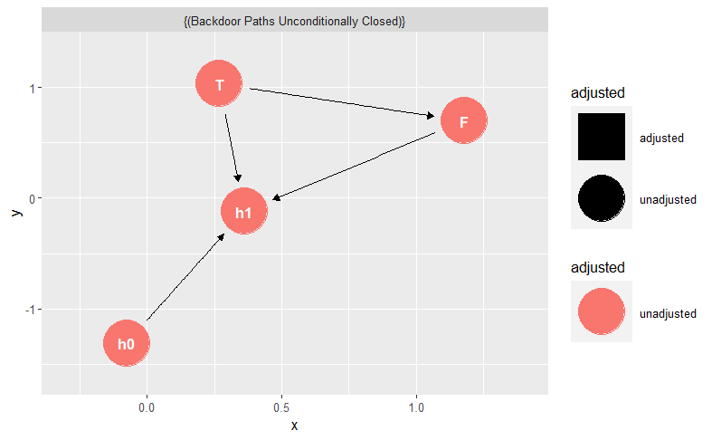

```r
ggdag_adjustment_set(dag_fungus1, effect = "total")
```

che ci dice che non dobbiamo includere alcuna variabile all’infuori delle interessate per avere una corretta stima dell’influenza causale di `T` su `h1` (nessun nodo è diventato quadrato). In sostanza ci dice di lasciare aperta la pipe, per far sì che l’influenza causale scorra anche attraverso quel percorso causale.

Attenzione però che la funzione non tiene conto dei descendant come `h0`! Pertanto i ragionamenti sui descendant spettano a noi. Abbiamo già visto che in questo caso `h0` aiuta la corretta stima e quindi lo includeremo.

```r
lm(data = fungus1, h1 ~ h0 + treatment) %>% summary()
```

```
Call:
lm(formula = h1 ~ h0 + treatment, data = fungus1)

Residuals:
    Min      1Q  Median      3Q     Max
-4.2379 -1.3624  0.4397  1.3783  3.8277

Coefficients:
            Estimate Std. Error t value Pr(>|t|)
(Intercept)   4.8031     0.9860   4.871 4.32e-06 ***
h0            0.8817     0.0961   9.175 8.12e-15 ***
treatment     1.9860     0.3911   5.078 1.84e-06 ***
---
Signif. codes:  0 ‘***’ 0.001 ‘**’ 0.01 ‘*’ 0.05 ‘.’ 0.1 ‘ ’ 1

Residual standard error: 1.955 on 97 degrees of freedom
Multiple R-squared:  0.5294,    Adjusted R-squared:  0.5197
F-statistic: 54.56 on 2 and 97 DF,  p-value: < 2.2e-16
```

tutto significativo! In questo caso il trattamento ha un impatto positivo doppio (confrontate i coefficienti con lo scorso esempio) nei confronti della crescita.

Come ricercatore però sono anche interessato a valutare l’impatto diretto che il mio trattamento ha sulla pianta. In altre parole, voglio sapere se ha un effetto benefico, ad esempio biostimolante, indipendentemente dalla presenza del fungo. In questo caso ho bisogno di calcolare l’effetto diretto del mio trattamento. Dato il DAG posso trovare l’adjustment set con:

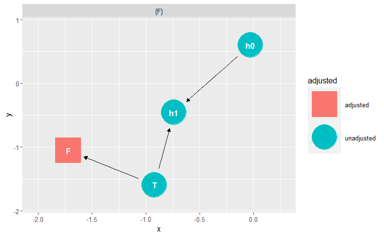

Per vedere l’effetto diretto in questo caso è necessario stratificare per la presenza del fungo in modo da chiudere il flusso associativo della pipe per lasciare aperto solamente quello tra `T` e `h1`.

Procediamo dunque con la regressione lineare:

```r
lm(data = fungus1, h1 ~  treatment + fungus + h0 ) %>% summary()
```

```
Call:
lm(formula = h1 ~ treatment + fungus + h0, data = fungus1)

Residuals:
     Min       1Q   Median       3Q      Max
-2.85715 -0.59537 -0.02372  0.62333  2.21295

Coefficients:
            Estimate Std. Error t value Pr(>|t|)
(Intercept)  6.61956    0.47174  14.032  < 2e-16 ***
treatment    0.83709    0.19317   4.333 3.62e-05 ***
fungus      -4.10071    0.22022 -18.621  < 2e-16 ***
h0           0.86381    0.04499  19.199  < 2e-16 ***
---
Signif. codes:  0 ‘***’ 0.001 ‘**’ 0.01 ‘*’ 0.05 ‘.’ 0.1 ‘ ’ 1

Residual standard error: 0.9152 on 96 degrees of freedom
Multiple R-squared:  0.898, Adjusted R-squared:  0.8948
F-statistic: 281.6 on 3 and 96 DF,  p-value: < 2.2e-16
```

tutto significativo: il trattamento in questo caso favorisce la crescita della pianta anche senza influenzare la presenza del fungo; in ipotesi potrebbe avere un effetto biostimolante oppure fornire nutrienti aggiuntivi che la pianta è capace di utilizzare.

### effetti totali e diretti del fungo

Ma cambiamo un attimo prospettiva. E se io fossi interessato a capire l’effetto del fungo sulla crescita? Posso farlo cambiando focus nel DAG su cos’è l’exposure e l’outcome. In questo caso, voglio che la mia exposure sia la presenza o meno del fungo e cerco l’adjustment set per l’effetto totale:

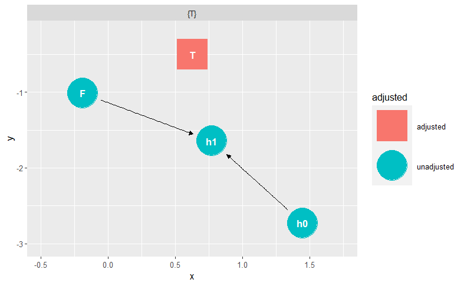

```r
set.seed(1)
ggdag_adjustment_set(dag_fungus1, exposure = "F", effect = "total")
```

e per l’effetto diretto:

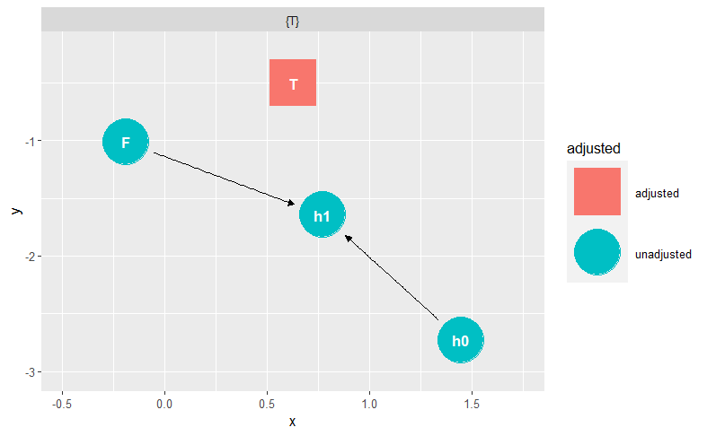

```r
set.seed(1)
ggdag_adjustment_set(dag_fungus1, exposure = "F", effect = "direct")
```

Da notare che in questo caso effetto diretto e totale coincidono: l’unico path che collega causalmente `F` con `h1` è un path causale diretto.

Passando all’adjustment set, devo stratificare per `T`, e ancora una volta per `h0` per i motivi già citati riguardo il descendant. Ma un momento… quindi userei le stesse covariate che ho usato per stimare l’effetto diretto del trattamento. In altre parole, il coefficiente del fungo in quella regressione rappresenta anche l’effetto diretto e totale del fungo sulla crescita della pianta. Non ci sorprende che esso abbia coefficiente negativo, infatti limita lo sviluppo della stessa.

### Approfondimento: primo esempio fungus

La prima volta che ho usato questo esempio del fungo, vi ho detto io che il trattamento non influiva sulla crescita della pianta. In altre parole vi ho detto che non c’erano effetti diretti tra il trattamento e l’altezza finale. L’ho fatto per passare più facilmente il concetto della pipe, ma ora possiamo riguardare l’esempio con altri occhi. Supponiamo di non sapere se il trattamento influisca o meno sulla cresita. Il DAG più plausibile è quello che abbiamo usato ora:

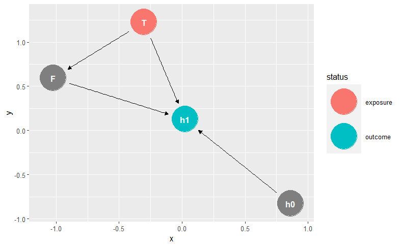

Quindi, facendo la regressione con i dati `fungus` otteniamo:

```r
fungus %>% lm(data = ., h1 ~ h0 + fungus + treatment) %>% summary()
```

```
Call:
lm(formula = h1 ~ h0 + fungus + treatment, data = .)

Residuals:
     Min       1Q   Median       3Q      Max
-2.85715 -0.59537 -0.02372  0.62333  2.21295

Coefficients:
            Estimate Std. Error t value Pr(>|t|)
(Intercept)  6.61956    0.47174  14.032   <2e-16 ***
h0           0.86381    0.04499  19.199   <2e-16 ***
fungus      -4.10071    0.22022 -18.621   <2e-16 ***
treatment   -0.16291    0.19317  -0.843    0.401
---
Signif. codes:  0 ‘***’ 0.001 ‘**’ 0.01 ‘*’ 0.05 ‘.’ 0.1 ‘ ’ 1

Residual standard error: 0.9152 on 96 degrees of freedom
Multiple R-squared:  0.8876,    Adjusted R-squared:  0.8841
F-statistic: 252.7 on 3 and 96 DF,  p-value: < 2.2e-16
```

In cui `fungus` ha coefficiente negativo (vi ricordo che misura la sua influenza diretta sulla crescita), mentre `treatment` ha coefficiente non significativo. Quel coefficiente sappiamo che indica l’effetto diretto del trattamento sulla crescita. Quindi in questo caso non possiamo rifiutare l’ipotesi nulla e quindi l’influenza del trattamento sulla crescita potrebbe essere zero, che è la stessa cosa di dire che non c’è la freccia che collega `T` ad `h1`.